# Hospital Appointment Management and Patient Attendance Analysis Using R

# 8 New patient prediction

The details below represent a fictional patient, with no known actual outcome.

New appointment details

| Age | Gender | Scholarship | Hipertension | Diabetes | Alcoholism | Handcap | SMS_received | WaitingDays |
| --- | --- | --- | --- | --- | --- | --- | --- | --- |
| 28 | M | 0 | 0 | 1 | 0 | 4 | 0 | 20 |

Attendance probabilities and follow-up

| Model | Attending_Percent | Missing_Percent | More_Probable_Outcome | Follow_Up_Flag |
| --- | --- | --- | --- | --- |
| Random Forest | 72.36 | 27.64 | Attended | Prioritize reminder or confirmation |
| XGBoost | 60.60 | 39.40 | Attended | Prioritize reminder or confirmation |

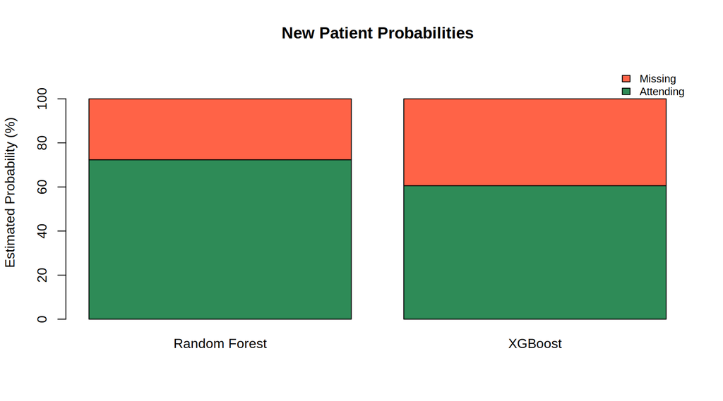

Attending and missing probabilities total approximately 100% after rounding. The more probable outcome uses 50%, while the reminder flag uses the selected validation threshold. Staff could use flags to prioritise confirmation calls. This demonstration does not validate the model or establish an operational benefit.

# 9 Model comparison and discussion

- **Random Forest:** precision 31.60%, recall 75.22%, F1 0.4450, Brier score 0.1516.
- **XGBoost:** precision 32.52%, recall 71.37%, F1 0.4468, Brier score 0.1505.

The analysis addresses attendance patterns and implements both probability models. Lower thresholds prioritise recall but create more unnecessary calls. The confusion matrices quantify this workload. Small differences in F1 do not establish a statistically reliable winner. The new-patient output demonstrates the interface between patient details, probability estimates and follow-up flags.

# 10 Limitations

- The working CSV may be a subset; its coverage must be documented.
- Patient-separated testing does not establish performance on future dates or other hospitals.
- Transport barriers, urgency and other relevant factors are absent.
- SMS status does not establish reading and must be known at prediction time.
- Threshold selection maximises F1 rather than hospital benefit or call capacity.
- Probability calibration and subgroup performance need further assessment.
- The test set was inspected during development; external evaluation would provide stronger evidence.
- Feature importance and descriptive graphs show associations, not causation.

# 11 Conclusion

The project prepares appointment records, analyses attendance patterns and fits Random Forest and XGBoost. Validation selects follow-up thresholds, and test results quantify probability quality and missed-appointment detection. The final output provides attending and missing probabilities with a separate reminder flag. This is a research prototype; practical use needs external validation and an assessment of follow-up costs and benefits.

## 11.1 Future work

- Verify complete source coverage and evaluate later appointments.
- Assess calibration and performance across patient groups.
- Choose thresholds according to reminder capacity and costs.
- Add an input interface and test whether targeted reminders improve attendance.

# 12 Reproducibility

This report renders saved experiment results without retraining models. Keep `report_data.rds` beside the report. To reproduce training, use the Colab notebook with the same CSV, split seed and package versions. Saving results does not by itself create Git history; version control must be maintained separately.

Render with `params = list(show_code = TRUE)` to display analysis code.